# INTRODUCTION

This project aimed to explore and analyze the given dataset by performing data preprocessing, comprehensive exploratory data analysis, and visualization to uncover trends, patterns, and correlations. The tasks undertaken ranged from correcting and cleaning data to deriving insights

```python
import warnings
import sys
if not sys.warnoptions:
    warnings.simplefilter("ignore")

import pandas as pd
import numpy as np
import matplotlib.pyplot as plt
import seaborn as sns
```

```python
data = pd.read_excel("myexcel.xlsx")
data
```

|  | Name | Team | Number | Position | Age | Height | Weight | College | Salary |
| --- | --- | --- | --- | --- | --- | --- | --- | --- | --- |
| 0 | Avery Bradley | Boston Celtics | 0 | PG | 25 | 2023-02-06 00:00:00 | 180 | Texas | 7730337.0 |
| 1 | Jae Crowder | Boston Celtics | 99 | SF | 25 | 2023-06-06 00:00:00 | 235 | Marquette | 6796117.0 |
| 2 | John Holland | Boston Celtics | 30 | SG | 27 | 2023-05-06 00:00:00 | 205 | Boston University | NaN |
| 3 | R.J. Hunter | Boston Celtics | 28 | SG | 22 | 2023-05-06 00:00:00 | 185 | Georgia State | 1148640.0 |
| 4 | Jonas Jerebko | Boston Celtics | 8 | PF | 29 | 2023-10-06 00:00:00 | 231 | NaN | 5000000.0 |
| ... | ... | ... | ... | ... | ... | ... | ... | ... | ... |
| 453 | Shelvin Mack | Utah Jazz | 8 | PG | 26 | 2023-03-06 00:00:00 | 203 | Butler | 2433333.0 |
| 454 | Raul Neto | Utah Jazz | 25 | PG | 24 | 2023-01-06 00:00:00 | 179 | NaN | 900000.0 |
| 455 | Tibor Pleiss | Utah Jazz | 21 | C | 26 | 2023-03-07 00:00:00 | 256 | NaN | 2900000.0 |
| 456 | Jeff Withey | Utah Jazz | 24 | C | 26 | 7-0 | 231 | Kansas | 947276.0 |
| 457 | Priyanka | Utah Jazz | 34 | C | 25 | 2023-03-07 00:00:00 | 231 | Kansas | 947276.0 |

458 rows × 9 columns

```python
data2 = data.copy()
data2
```

|  | Name | Team | Number | Position | Age | Height | Weight | College | Salary |
| --- | --- | --- | --- | --- | --- | --- | --- | --- | --- |
| 0 | Avery Bradley | Boston Celtics | 0 | PG | 25 | 2023-02-06 00:00:00 | 180 | Texas | 7730337.0 |
| 1 | Jae Crowder | Boston Celtics | 99 | SF | 25 | 2023-06-06 00:00:00 | 235 | Marquette | 6796117.0 |
| 2 | John Holland | Boston Celtics | 30 | SG | 27 | 2023-05-06 00:00:00 | 205 | Boston University | NaN |
| 3 | R.J. Hunter | Boston Celtics | 28 | SG | 22 | 2023-05-06 00:00:00 | 185 | Georgia State | 1148640.0 |
| 4 | Jonas Jerebko | Boston Celtics | 8 | PF | 29 | 2023-10-06 00:00:00 | 231 | NaN | 5000000.0 |
| ... | ... | ... | ... | ... | ... | ... | ... | ... | ... |
| 453 | Shelvin Mack | Utah Jazz | 8 | PG | 26 | 2023-03-06 00:00:00 | 203 | Butler | 2433333.0 |
| 454 | Raul Neto | Utah Jazz | 25 | PG | 24 | 2023-01-06 00:00:00 | 179 | NaN | 900000.0 |
| 455 | Tibor Pleiss | Utah Jazz | 21 | C | 26 | 2023-03-07 00:00:00 | 256 | NaN | 2900000.0 |
| 456 | Jeff Withey | Utah Jazz | 24 | C | 26 | 7-0 | 231 | Kansas | 947276.0 |
| 457 | Priyanka | Utah Jazz | 34 | C | 25 | 2023-03-07 00:00:00 | 231 | Kansas | 947276.0 |

458 rows × 9 columns

```python
data.isnull().sum()
```

```
Name         0
Team         0
Number       0
Position     0
Age          0
Height       0
Weight       0
College     84
Salary      11
dtype: int64
```

# PREPROCESSING

Correct the data in the Height column by replacing it with random numbers between 150 and 180. Ensure data consistency and integrity before proceeding with analysis.

```python
# import numpy as np
data['Height'] = np.random.randint(150,181,size = len(data))
data.head(10)
```

|  | Name | Team | Number | Position | Age | Height | Weight | College | Salary |
| --- | --- | --- | --- | --- | --- | --- | --- | --- | --- |
| 0 | Avery Bradley | Boston Celtics | 0 | PG | 25 | 152 | 180 | Texas | 7730337.0 |
| 1 | Jae Crowder | Boston Celtics | 99 | SF | 25 | 159 | 235 | Marquette | 6796117.0 |
| 2 | John Holland | Boston Celtics | 30 | SG | 27 | 159 | 205 | Boston University | NaN |
| 3 | R.J. Hunter | Boston Celtics | 28 | SG | 22 | 165 | 185 | Georgia State | 1148640.0 |
| 4 | Jonas Jerebko | Boston Celtics | 8 | PF | 29 | 152 | 231 | NaN | 5000000.0 |
| 5 | Amir Johnson | Boston Celtics | 90 | PF | 29 | 158 | 240 | NaN | 12000000.0 |
| 6 | Jordan Mickey | Boston Celtics | 55 | PF | 21 | 156 | 235 | LSU | 1170960.0 |
| 7 | Kelly Olynyk | Boston Celtics | 41 | C | 25 | 170 | 238 | Gonzaga | 2165160.0 |
| 8 | Terry Rozier | Boston Celtics | 12 | PG | 22 | 168 | 190 | Louisville | 1824360.0 |
| 9 | Marcus Smart | Boston Celtics | 36 | PG | 22 | 178 | 220 | Oklahoma State | 3431040.0 |

### Replace null values in 'Salary' with the mean

```python
data['Salary'].fillna(data['Salary'].mean(), inplace=True)
data
```

|  | Name | Team | Number | Position | Age | Height | Weight | College | Salary |
| --- | --- | --- | --- | --- | --- | --- | --- | --- | --- |
| 0 | Avery Bradley | Boston Celtics | 0 | PG | 25 | 152 | 180 | Texas | 7.730337e+06 |
| 1 | Jae Crowder | Boston Celtics | 99 | SF | 25 | 159 | 235 | Marquette | 6.796117e+06 |
| 2 | John Holland | Boston Celtics | 30 | SG | 27 | 159 | 205 | Boston University | 4.833970e+06 |
| 3 | R.J. Hunter | Boston Celtics | 28 | SG | 22 | 165 | 185 | Georgia State | 1.148640e+06 |
| 4 | Jonas Jerebko | Boston Celtics | 8 | PF | 29 | 152 | 231 | NaN | 5.000000e+06 |
| ... | ... | ... | ... | ... | ... | ... | ... | ... | ... |
| 453 | Shelvin Mack | Utah Jazz | 8 | PG | 26 | 157 | 203 | Butler | 2.433333e+06 |
| 454 | Raul Neto | Utah Jazz | 25 | PG | 24 | 156 | 179 | NaN | 9.000000e+05 |
| 455 | Tibor Pleiss | Utah Jazz | 21 | C | 26 | 177 | 256 | NaN | 2.900000e+06 |
| 456 | Jeff Withey | Utah Jazz | 24 | C | 26 | 151 | 231 | Kansas | 9.472760e+05 |
| 457 | Priyanka | Utah Jazz | 34 | C | 25 | 159 | 231 | Kansas | 9.472760e+05 |

458 rows × 9 columns

# ANALYSIS TASKS

1. Determine the distribution of employees across each team and calculate the percentage split relative to the total number of employees.

```python
# Calculate the distribution of players across each team
team_distribution = data['Team'].value_counts()

# Calculate the percentage split relative to the total number of players
team_percentage = (team_distribution/len(data))*100

team_stats = pd.DataFrame({
    'Player Count': team_distribution,
    'Percentage(%)': team_percentage.round(2)
})

team_stats.reset_index(inplace = True)
team_stats.rename(columns={'index':'Team'},inplace=True)

print(team_stats)
```

```
                      Team  Player Count  Percentage(%)
0     New Orleans Pelicans            19           4.15
1        Memphis Grizzlies            18           3.93
2                Utah Jazz            16           3.49
3          New York Knicks            16           3.49
4          Milwaukee Bucks            16           3.49
5            Brooklyn Nets            15           3.28
6   Portland Trail Blazers            15           3.28
7    Oklahoma City Thunder            15           3.28
8           Denver Nuggets            15           3.28
9       Washington Wizards            15           3.28
10              Miami Heat            15           3.28
11       Charlotte Hornets            15           3.28
12           Atlanta Hawks            15           3.28
13       San Antonio Spurs            15           3.28
```

[output cut: 16 more lines]

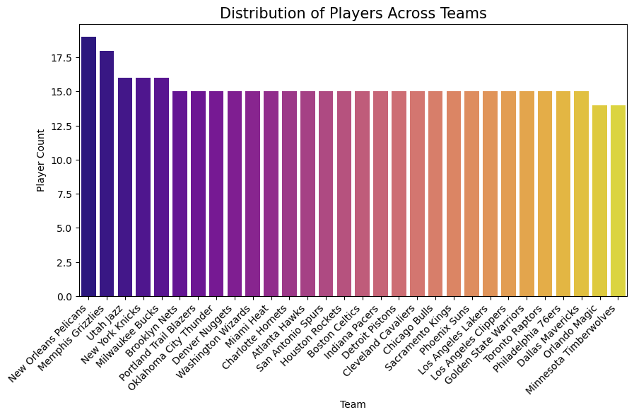

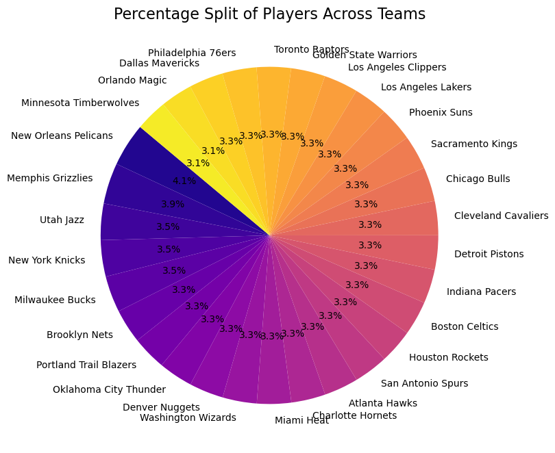

```python
# import matplotlib.pyplot as plt
# import seaborn as sns

# Plotting the number of players across each team as a bar chart
plt.figure(figsize = (10,5))
sns.barplot(x = team_stats['Team'], y = team_stats['Player Count'], palette = 'plasma')
plt.title('Distribution of Players Across Teams', fontsize = 15)
plt.xlabel('Team', fontsize = 10)
plt.ylabel('Player Count', fontsize = 10)
plt.xticks(rotation = 45, ha = 'right')
plt.show()

# Plotting the percentage split as a pie chart
plt.figure(figsize = (8,8))
plt.pie(team_stats['Percentage(%)'], labels = team_stats['Team'], autopct = '%1.1f%%',
        startangle = 140, colors = sns.color_palette('plasma', len(team_stats)))
plt.title('Percentage Split of Players Across Teams', fontsize = 16)
plt.show()
```

2. Segregate employees based on their positions within the company.

```python
# Segregate players based on their positions
position_groups = data.groupby('Position')

# Create a dictionary where each key is a position and the value is the corresponding player data
position_dict = {position: group for position, group in position_groups}

# Display the first few rows for each position as an example
for position, group in position_dict.items():
    print(f"Position: {position}")
    print(group.head(), '\n')
```

```
Position: C
               Name            Team  Number Position  Age  Height  Weight  \
7      Kelly Olynyk  Boston Celtics      41        C   25     170     238
10  Jared Sullinger  Boston Celtics       7        C   24     154     260
14     Tyler Zeller  Boston Celtics      44        C   26     176     253
23      Brook Lopez   Brooklyn Nets      11        C   28     161     275
27       Henry Sims   Brooklyn Nets      14        C   26     166     248

           College      Salary
7          Gonzaga   2165160.0
10      Ohio State   2569260.0
14  North Carolina   2616975.0
23        Stanford  19689000.0
27      Georgetown    947276.0

Position: PF
                Name            Team  Number Position  Age  Height  Weight  \
4      Jonas Jerebko  Boston Celtics       8       PF   29     152     231
5       Amir Johnson  Boston Celtics      90       PF   29     158     240
6      Jordan Mickey  Boston Celtics      55       PF   21     156     235
24  Chris McCullough   Brooklyn Nets       1       PF   21     161     200
25       Willie Reed   Brooklyn Nets      33       PF   26     165     220

        College      Salary
4           NaN   5000000.0
5           NaN  12000000.0
6           LSU   1170960.0
24     Syracuse   1140240.0
25  Saint Louis    947276.0

Position: PG
             Name            Team  Number Position  Age  Height  Weight  \
0   Avery Bradley  Boston Celtics       0       PG   25     152     180
8    Terry Rozier  Boston Celtics      12       PG   22     168     190
9    Marcus Smart  Boston Celtics      36       PG   22     178     220
11  Isaiah Thomas  Boston Celtics       4       PG   27     164     185
19   Jarrett Jack   Brooklyn Nets       2       PG   32     170     200

           College     Salary
0            Texas  7730337.0
```

[output cut: 19 more lines]

```

Position: SG
                Name            Team  Number Position  Age  Height  Weight  \
2       John Holland  Boston Celtics      30       SG   27     159     205
3        R.J. Hunter  Boston Celtics      28       SG   22     165     185
12       Evan Turner  Boston Celtics      11       SG   27     169     220
13       James Young  Boston Celtics      13       SG   20     155     215
15  Bojan Bogdanovic   Brooklyn Nets      44       SG   27     166     216

              College        Salary
2   Boston University  4.833970e+06
3       Georgia State  1.148640e+06
12         Ohio State  3.425510e+06
13           Kentucky  1.749840e+06
15                NaN  3.425510e+06
```

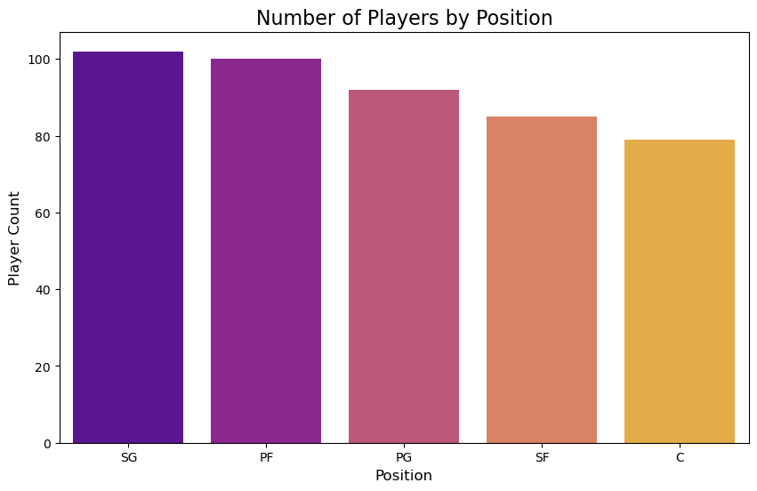

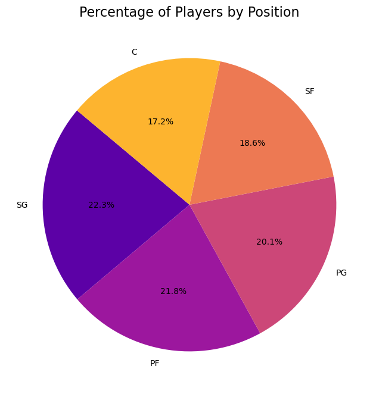

```python
# import matplotlib.pyplot as plt
# import seaborn as sns

# Count the number of players in each position
position_distribution = data['Position'].value_counts()

# Bar Chart: Distribution of players across positions
plt.figure(figsize = (10,6))
sns.barplot(x = position_distribution.index, y = position_distribution.values, palette = "plasma")
plt.title('Number of Players by Position', fontsize = 16)
plt.xlabel('Position', fontsize = 12)
plt.ylabel('Player Count', fontsize = 12)
plt.xticks(fontsize = 10)
plt.show()

# Pie Chart: Percentage distribution of players across positions
plt.figure(figsize = (8,8))
plt.pie(position_distribution.values, labels = position_distribution.index, autopct = '%1.1f%%',
        startangle = 140, colors = sns.color_palette('plasma', len(position_distribution)))
plt.title('Percentage of Players by Position', fontsize = 16)
plt.show()
```

3. Identify the predominant age group among employees.

```python
# import pandas as pd

# Define age bins and labels
bins = [0,20,25,30,35,40] #Age range
labels = ['<20','20-25','26-30','31-35','>=35']

# Categorize players into age groups
data['Age Group'] = pd.cut(data['Age'], bins = bins, labels = labels, right = False)

# Calculate distribution of players across age groups
age_group_distribution = data['Age Group'].value_counts().sort_index()
age_group_distribution.name = "Age Distribution"

# Identify predominant age group
predominant_age_group = age_group_distribution.idxmax()

# Display the results
print("Distribution of players by age group:")
print(age_group_distribution)
print("\nPredominant age group:", predominant_age_group)
```

```
Distribution of players by age group:
Age Group
<20        2
20-25    152
26-30    182
31-35     90
>=35      29
Name: Age Distribution, dtype: int64

Predominant age group: 26-30
```

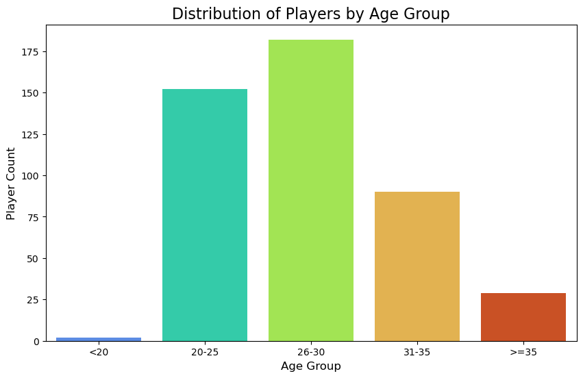

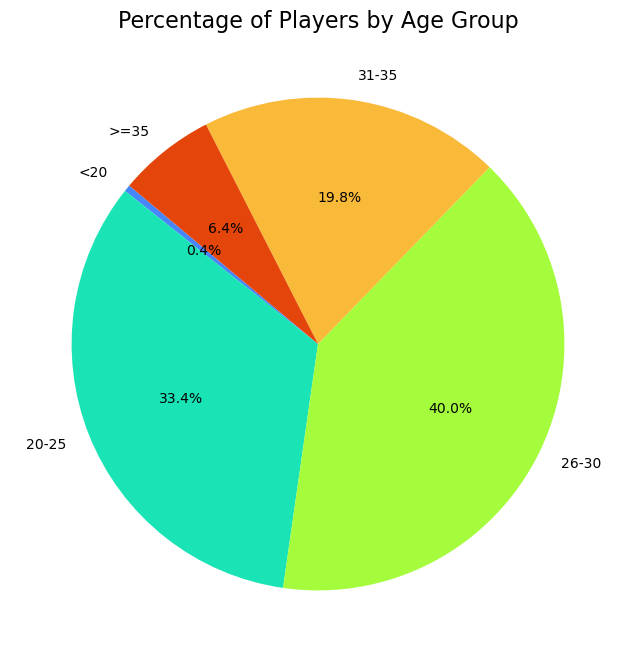

```python
# import matplotlib.pyplot as plt
# import seaborn as sns

# Bar Chart: Distribution of players by age group
plt.figure(figsize = (10,6))
sns.barplot(x = age_group_distribution.index, y = age_group_distribution.values, palette = "turbo")
plt.title("Distribution of Players by Age Group", fontsize = 16)
plt.xlabel('Age Group', fontsize = 12)
plt.ylabel('Player Count', fontsize = 12)
plt.xticks(fontsize = 10)
plt.show()

# Pie Chart: Percentage of players by age group
plt.figure(figsize = (8,8))
plt.pie(age_group_distribution.values, labels = age_group_distribution.index, autopct = '%1.1f%%',
        startangle = 140, colors = sns.color_palette('turbo', len(age_group_distribution)))
plt.title("Percentage of Players by Age Group", fontsize = 16)
plt.show()
```

4. Discover which team and position have the highest salary expenditure.

```python
# Calculate the total salary expenditure by a team
team_salary_expenditure = data.groupby('Team')['Salary'].sum().sort_values(ascending = False)
team_salary_expenditure.name = "Team Salary"

# Calculate total salary expenditure by position
position_salary_expenditure = data.groupby('Position')['Salary'].sum().sort_values(ascending = False)
position_salary_expenditure.name = "Position Salary"

# Identify the team and position with the highest salary expenditure
highest_team_salary = team_salary_expenditure.idxmax()
highest_position_salary = position_salary_expenditure.idxmax()

# Display the results
print("Total Salary Expenditure by Team:")
print(team_salary_expenditure, "\n")
print(f"Team with the highest salary expenditure: {highest_team_salary} (${team_salary_expenditure.max():,.2f})\n")

print("Total Salary Expenditure by Position:")
print(position_salary_expenditure, "\n")
print(f"Position with the highest salary expenditure: {highest_position_salary} (${position_salary_expenditure.max():,.2f})\n")
```

```
Total Salary Expenditure by Team:
Team
Cleveland Cavaliers       1.118227e+08
Memphis Grizzlies         9.588676e+07
Los Angeles Clippers      9.485464e+07
Oklahoma City Thunder     9.376530e+07
Miami Heat                9.218361e+07
Golden State Warriors     8.886900e+07
Chicago Bulls             8.678338e+07
San Antonio Spurs         8.444273e+07
New Orleans Pelicans      8.275077e+07
Charlotte Hornets         7.834092e+07
Washington Wizards        7.632864e+07
Houston Rockets           7.528302e+07
New York Knicks           7.330390e+07
Atlanta Hawks             7.290295e+07
Los Angeles Lakers        7.177043e+07
Sacramento Kings          7.168367e+07
Dallas Mavericks          7.119873e+07
Toronto Raptors           7.111761e+07
Milwaukee Bucks           6.960352e+07
Detroit Pistons           6.716826e+07
Indiana Pacers            6.675183e+07
Denver Nuggets            6.495590e+07
Minnesota Timberwolves    6.454367e+07
Utah Jazz                 6.400737e+07
Phoenix Suns              6.344514e+07
Boston Celtics            6.337504e+07
Orlando Magic             6.016147e+07
Brooklyn Nets             5.252848e+07
Portland Trail Blazers    4.830182e+07
Philadelphia 76ers        3.582686e+07
Name: Team Salary, dtype: float64

Team with the highest salary expenditure: Cleveland Cavaliers ($111,822,658.55)

Total Salary Expenditure by Position:
Position
C     4.663773e+08
PG    4.661848e+08
PF    4.570628e+08
SF    4.128549e+08
SG    4.114782e+08
Name: Position Salary, dtype: float64

Position with the highest salary expenditure: C ($466,377,332.00)
```

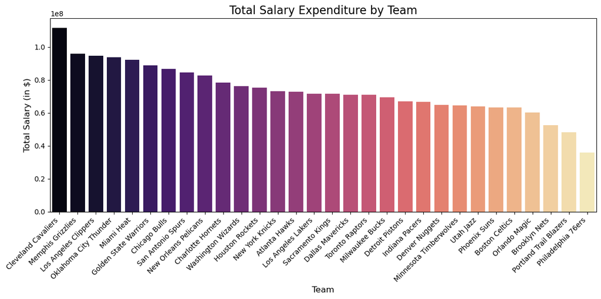

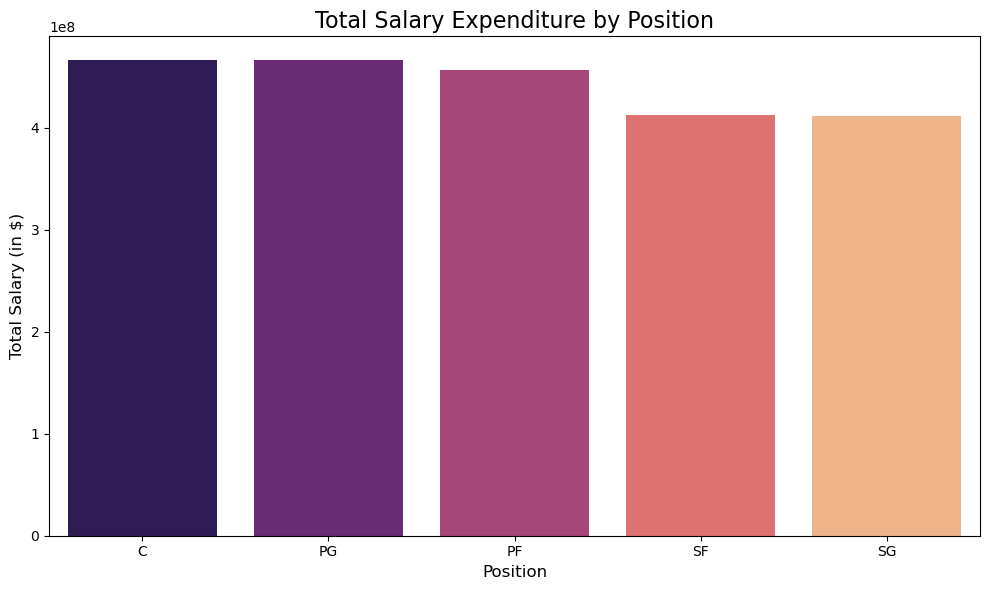

```python
# import matplotlib.pyplot as plt
# import seaborn as sns

# Bar Chart: Total salary expenditure by team
plt.figure(figsize = (12, 6))
sns.barplot(x = team_salary_expenditure.index, y = team_salary_expenditure.values, palette = "magma")
plt.title('Total Salary Expenditure by Team', fontsize = 16)
plt.xlabel('Team', fontsize = 12)
plt.ylabel('Total Salary (in $)', fontsize = 12)
plt.xticks(rotation = 45, ha = 'right', fontsize = 10)
plt.tight_layout()
plt.show()

# Bar Chart: Total salary expenditure by position
plt.figure(figsize = (10, 6))
sns.barplot(x = position_salary_expenditure.index, y = position_salary_expenditure.values, palette = "magma")
plt.title('Total Salary Expenditure by Position', fontsize = 16)
plt.xlabel('Position', fontsize = 12)
plt.ylabel('Total Salary (in $)', fontsize = 12)
plt.xticks(fontsize = 10)
plt.tight_layout()
plt.show()
```

5. Investigate if there is any correlation between age and salary, and represent it visually.

```python
# Calculate the correlation betweenn Age and Salary
correlation = data['Age'].corr(data['Salary'])
print(f"The correlation between Age and Salary is: {correlation:.2f}")

# Determine the type of correlation
if correlation > 0:
    correlation_type = 'Positive Correlation'
elif correlation < 0:
    correlation_type = 'Negative Correlation'
else:
    correlation_type = 'No Correlation'

# Display correlation type
print(f"The correlation between Age and Salary is: {correlation_type}")
```

```
The correlation between Age and Salary is: 0.21
The correlation between Age and Salary is: Positive Correlation
```

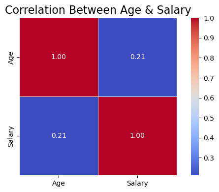

```python
# import seaborn as sns
# import matplotlib.pyplot as plt

# Calculate the correlation matrix
correlation_matrix = data[['Age','Salary']].corr()

# Plot the heatmap
plt.figure(figsize = (6,4))
sns.heatmap(correlation_matrix, annot = True, cmap = "coolwarm", fmt = '.2f', linewidth = 0.5, cbar = True, square = True)

# Customize the plot
plt.title("Correlation Between Age & Salary", fontsize = 16)
plt.xticks(fontsize = 10)
plt.yticks(fontsize = 10)
plt.tight_layout()
plt.show()
```

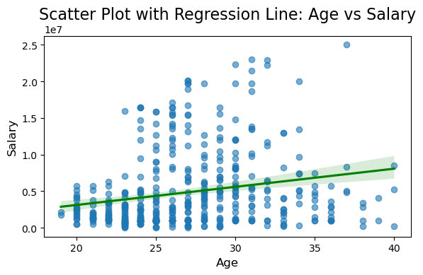

```python
# Import seaborn and matplotlib.pyplot
import seaborn as sns
import matplotlib.pyplot as plt

# Plot the scatter plot with regression line
plt.figure(figsize=(6, 4))
sns.regplot(x='Age', y='Salary', data=data, scatter_kws={'alpha': 0.6}, line_kws={'color': 'green'})

# Customize the plot
plt.title("Scatter Plot with Regression Line: Age vs Salary", fontsize=16)
plt.xlabel("Age", fontsize=12)
plt.ylabel("Salary", fontsize=12)
plt.xticks(fontsize=10)
plt.yticks(fontsize=10)
plt.tight_layout()
plt.show()
```

# OVERVIEW

## ANALYSIS TASKS AND INSIGHTS

### 1. Distribution of Players Across Teams:

Objective: Determine the number of players in each team and calculate the percentage split relative to the total players.

Visualization: A bar chart was created to display the distribution of players across teams and their relative percentages.

### 2. Segregation of Players by Position:

Objective: Group players based on their positions and understand the overall positional breakdown.

Insight: Positional roles such as "Shooting Guard (SG)" and "Power Forward (PF)" dominated, while specialized roles like "Centre (C)" had fewer players.

Visualization: A pie chart depicted the positional distribution, clearly showing the proportions of each role.

### 3. Predominant Age Group:

Objective: Analyze the age distribution of players and identify the predominant age group.

Insight: Most players fell into the 20-30 age bracket, emphasizing the dominance of younger players in the dataset. Few players were below 20 or above 35, aligning with typical professional sports age trends.

Visualization: A histogram of age distribution, with bins indicating age ranges, provided clarity on the player demographics.

### 4. Salary Analysis by Team and Position:

Objective: Discover which team and position had the highest salary expenditure.

Insight: Cleveland Cavaliers had the highest salary expenditure, significantly surpassing other teams. For positions, "Centre (C)" and "Point Guard (PG)" had the highest salary allocation, reflecting its importance in the game.

### 5. Correlation Between Age and Salary:

Objective: Investigate the relationship between players' age and their salary.

Insight: A weak positive correlation was observed, indicating that salary tended to increase slightly with age but not significantly.

Visualization: A heat map and a scatter plot with regression line visually depicted the weak correlation between age and salary.

## ADDITIONAL INFORMATION

Further Steps for Analysis:

1. Performance Metrics: Incorporate performance metrics like points scored, assists, or tackles to analyze their impact on salary.
2. Geographical Analysis: If location data is available, we can investigate regional differences in player distributions and salaries.
3. Salary vs. Experience: Analyze whether experience (e.g., years in the league) correlates more strongly with salary than age.

Potential Improvements:

1. Enhanced Visualizations: Use interactive dashboards with tools like Tableau or Power BI for dynamic exploration.
2. Predictive Modeling: Build a regression model to predict salaries based on attributes like age, position, and team.